# 日本Pandocユーザ会の紹介

niszet

2020/12/05

## 自己紹介

- なまえ : niszet
- R歴 : 4年目(?)
- Twitter : @niszet0
- GitHub : https://github.com/niszet

## Pandocとは

- Haskell言語で書かれた文書形式変換ツール
- 大量のファイル形式に対応している（下図は https://pandoc.org/ より引用）

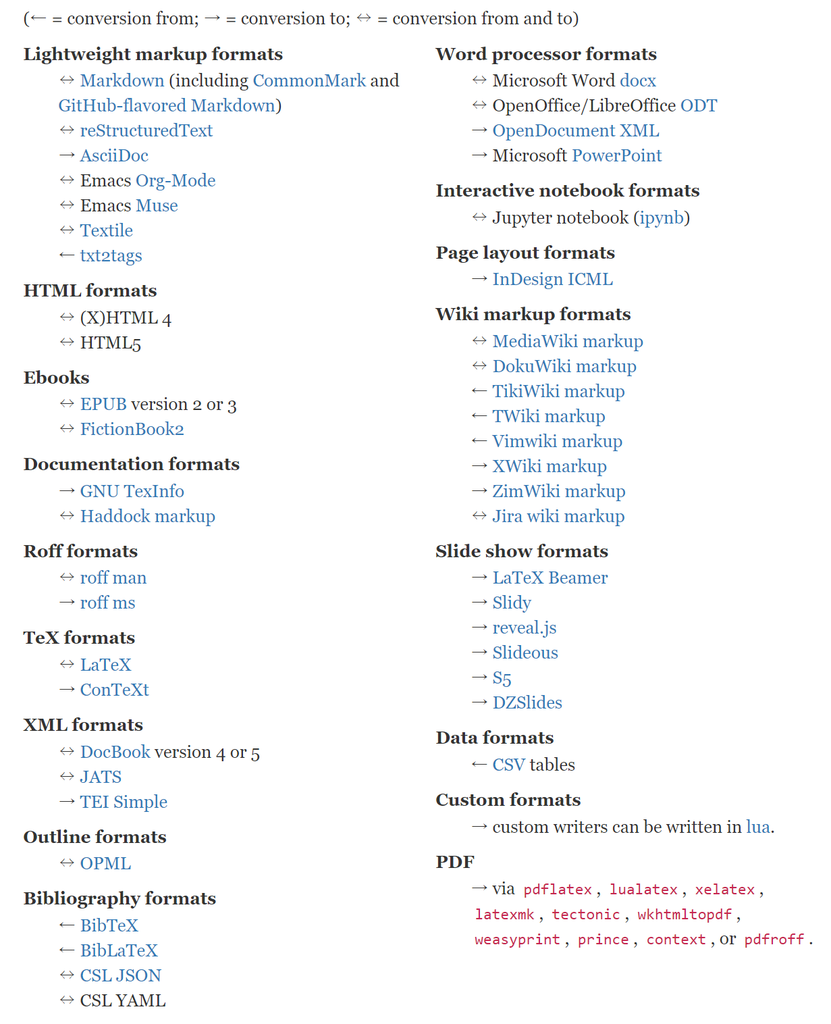

- RMarkdownで使用している`knitr`や`rmarkdown`パッケージはこのPandocを呼び出して文書の変換をしている。

## 日本Pandocユーザ会とは

[日本Pandocユーザ会 のHP](http://sky-y.github.io/site-pandoc-jp/)によると、

```
この組織はドキュメント変換ツールPandoc (http://johnmacfarlane.net/pandoc/index.html) の
普及および情報共有を目的とした任意団体です。 （現在のところ非公式です。）
```

となってます。  
特にコレをやる！と決まって動いているわけではないですが…主に、

- Pandocのマニュアルの翻訳
- Slackでの情報共有

を行っています。

日本Pandocユーザ会のSlackは誰でも参加できます。  
登録はこちらから！  
[Slack登録フォーム (日本Pandocユーザ会)](https://docs.google.com/forms/d/e/1FAIpQLSc4bRaaw_t_J17LIvCiJ-CndWhFj3Et0rKSxkJbPG4VkpTfrA/viewform)

## 日本Pandocユーザ会 2020年の活動

2020年の活動内容は[Pandoc Advent Calendar 2020](https://adventar.org/calendars/4963) の1日目の記事にまとまっています。  
[2020年の日本Pandocユーザ会の動向 (藤原 惟)](https://zenn.dev/sky_y/articles/pandoc-advent-2020-user-group)

- マニュアルの翻訳(v2.7.2)
  - [Pandocユーザーズガイド 日本語版 [2.7.2]](https://pandoc-doc-ja.readthedocs.io/ja/v2.7.2/users-guide.html)  
    v2.7.2の時点のマニュアルの翻訳としてfix
  - 最新版（[Pandoc User’s Guide 日本語版](https://pandoc-doc-ja.readthedocs.io/ja/latest/users-guide.html)）は翻訳中…。
    - Pandocの更新速度に追いつけない…
- 行動規範の草案の作成  
  [日本Pandocユーザ会 行動規範 草案 2020-10-31](https://gist.github.com/sky-y/803772f3b79f762d631d2cc77d06133b#file-2020-10-31_code-of-conduct-draft-md)
- [Pandoc Advent Calendar 2020](https://adventar.org/calendars/4963) もまだまだ募集中です！

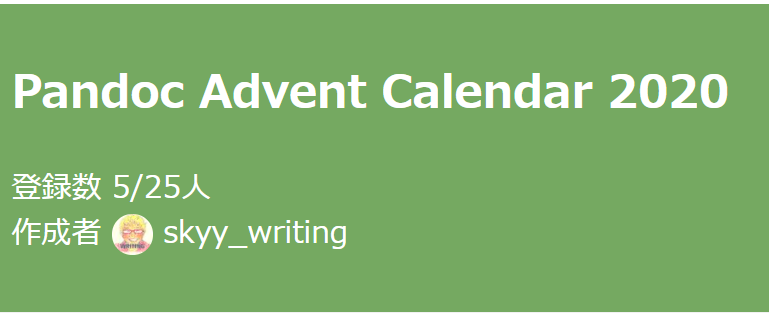

## niszetの2020年の活動

- Pandoc
  - ODT形式（LibreOffice）でtoc-depthの対応
  - OpenDocument形式でシンタックスハイライトの出力対応（ODT形式としては未完了）

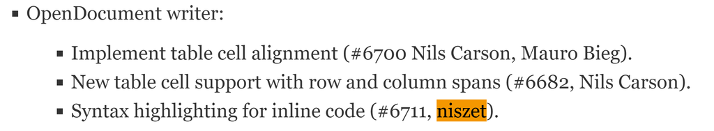

  - 今年はPandoc本体にもcontributed.
- Twitterアカウント新設
  - [JaPandoc Tips](https://twitter.com/JaPandocTips) アカウント作成（名前は`@atusy`氏、アイコンや画像は`@sky_y`氏提供）  
    Pandoc関連のTipsを呟いていく予定（まだほとんど呟いていない…💦）

[figure not shown]

## 2021年以降の活動予定

- 日本Pandocユーザ会の活動の予定
  - Pandoc Nightの開催を…
    - 参考: [Pandoc Night 2019](https://pandoc-jp.connpass.com/event/129083/)
  - Pandoc最新版のマニュアルの翻訳（今日時点で最新はpandoc 2.11.2）
  - SlackでのPandocの質問も募集中
    - pandoc-discuss は英語なので質問しづらいという人にも活用してほしい
- niszetの個人活動
  - ユーザ会の活動サポート
  - ODT形式のReader/Writerの更新
  - AdciiDoc/AdciiDoctor形式のReaderの作成
  - JaPandoc Tips でTipsを呟いていきたい

## Enjoy !

日本Pandocユーザ会 Slackの登録はこちらから！  
[Slack登録フォーム (日本Pandocユーザ会)](https://docs.google.com/forms/d/e/1FAIpQLSc4bRaaw_t_J17LIvCiJ-CndWhFj3Et0rKSxkJbPG4VkpTfrA/viewform)